V The V Lab

# Poisson Regression and Zero-Inflated Models in Depth

From counts, exposure, and overdispersion through negative binomial models, zero-inflated Poisson models, diagnostics, and reporting

School of Public Health Learning Module

Updated August 12, 2026

**Audience**Learners in public health, epidemiology, medicine, and health data science

**Study time**Approximately 150–210 minutes

**Prerequisites**Basic regression, likelihood, confidence intervals, and R

About the simulated data This module uses a fixed-seed simulated public-health cohort of respiratory emergency-department visits. Follow-up differs in person-years, and some people have structural zeros because their care is outside the participating-capture system. The data contain no real people or clinical records.

## How to use this tutorial

> **Define the event and the exposure → inspect the count distribution → fit a Poisson rate model → assess dispersion and zeros → choose an interpretable extension → check predictions and calibration → report the design and limitations.**

The word “zero-inflated” names a probability model, not a diagnosis. Start with the data-generating and measurement processes; then ask whether a mixture model answers a meaningful question.

### Learning objectives

After completing this tutorial, you should be able to:

- distinguish a count, a rate, a risk, and a probability of zero;
- specify and interpret a Poisson regression with `offset(log(person_years))`;
- convert a log-rate coefficient to an incidence rate ratio (IRR), confidence interval, and absolute prediction;
- calculate Pearson dispersion and explain common sources of overdispersion;
- compare Poisson, quasi-Poisson, negative binomial, and zero-inflated Poisson (ZIP) approaches;
- write the ZIP likelihood and interpret both its count and structural-zero components;
- obtain ZIP predictions for the susceptible count mean, structural-zero probability, marginal mean, and observed-zero probability;
- assess observed-versus-predicted frequency distributions and calibration without treating AIC as a scientific verdict;
- distinguish ZIP from a hurdle model;
- recognize the limits imposed by missing data, clustering, study design, and causal questions; and
- produce an auditable count-model report.

# 1 The question, outcome, and denominator

## 1.1 Count, rate, risk, and probability are different quantities

A **count** is the number of observed events: 3 respiratory emergency-department (ED) visits. A **rate** divides events by person-time: 3 visits in 1.5 person-years equals 2 visits per person-year. A **risk** is the probability of at least one event in a specified interval, which needs a fixed follow-up definition and is not generally the same as a rate. A zero probability, $P(Y=0)$, is neither an IRR nor a risk unless the outcome and observation window make it one.

For person $i$, let $Y_i$ be ED visits and $t_i$ be observed person-years. A Poisson rate model assumes

$$Y_i\mid X_i \sim \operatorname{Poisson}(\mu_i), \qquad
\log(\mu_i)=\log(t_i)+\beta_0+X_i^T\beta.$$

The coefficient of `log(t_i)` is fixed at one. It is an **offset**, not a covariate whose association is estimated. Thus $\exp(X_i^T\beta)$ is an expected event rate per person-year, and exponentiated covariate coefficients are IRRs holding other modeled predictors fixed.

Do not divide the outcome and then also use an offset For unequal observation time, model the integer count with `offset(log(person_years))`. A linear model for `visits/person_years` has the wrong error structure, gives unstable weight to short follow-up, and should not be combined with the offset as though it were a second correction.

## 1.2 The teaching cohort

The simulated cohort has $n=2400$ people. Program participation, smoking, severity, rural residence, and age influence the rate while access barriers and rural residence influence whether care is outside capture. This mechanism deliberately creates more zeros than a one-process Poisson model expects.

```r
summary_table <- data.frame(
  Quantity = c("People", "Total visits", "Person-years", "Observed zero visits",
               "Mean visits", "Variance of visits", "Mean follow-up"),
  Value = c(nrow(count_data), sum(count_data$visits), sum(count_data$person_years),
            sum(count_data$visits == 0), mean(count_data$visits), var(count_data$visits),
            mean(count_data$person_years))
)
knitr::kable(summary_table, digits = 2,
  caption = "Descriptive summary of the simulated respiratory ED-visit cohort")
```

Descriptive summary of the simulated respiratory ED-visit cohort

| Quantity | Value |
| --- | --- |
| People | 2400.00 |
| Total visits | 1717.00 |
| Person-years | 2926.23 |
| Observed zero visits | 1451.00 |
| Mean visits | 0.72 |
| Variance of visits | 1.29 |
| Mean follow-up | 1.22 |

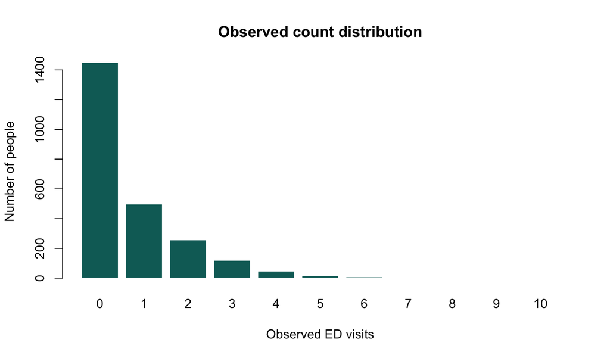

The distribution of observed respiratory ED-visit counts has a large bar at zero and a decreasing right tail. This plot motivates diagnosis but does not by itself identify a zero-inflated process.

```r
count_tab <- table(factor(count_data$visits, levels = 0:max(count_data$visits)))
barplot(count_tab, col = palette_count["teal"], border = "white", xlab = "Observed ED visits",
        ylab = "Number of people", main = "Observed count distribution")
```

## 1.3 Before modeling: data audit and complete cases

The outcome must be a nonnegative integer; identify whether a zero means no event, no opportunity, a recording rule, or an unobserved event. Confirm that person-time is positive and belongs to the same observation period as the count. Check duplicate rows, impossible dates, coding changes, and whether care outside a network is observed.

```r
analysis_variables <- c("visits", "person_years", "program", "smoking", "severity",
                        "rural", "age_c10", "access_barrier")
complete_rows <- complete.cases(count_data[, analysis_variables])
data.frame(
  Eligible_rows = nrow(count_data), Complete_rows = sum(complete_rows),
  Excluded_for_missingness = sum(!complete_rows),
  Minimum_person_years = min(count_data$person_years),
  Maximum_person_years = max(count_data$person_years)
)
```

| Eligible_rows | Complete_rows | Excluded_for_missingness | Minimum_person_years | Maximum_person_years |
| --- | --- | --- | --- | --- |
| 2400 | 2400 | 0 | 0.45 | 2 |

This simulated example is complete by construction. In a study, complete-case analysis is unbiased only under restrictive conditions; report missingness by variable and use a prespecified approach such as multiple imputation when justified. Do not impute the event count or person-time casually: the imputation model must honor their measurement process.

# 2 Poisson regression for rates

## 2.1 Fit the model and inspect the linear predictor

```r
poisson_fit <- glm(
  visits ~ program + smoking + severity + rural + age_c10 + offset(log(person_years)),
  family = poisson(link = "log"), data = count_data
)
poisson_fit
```

```
##
## Call:  glm(formula = visits ~ program + smoking + severity + rural +
##     age_c10 + offset(log(person_years)), family = poisson(link = "log"),
##     data = count_data)
##
## Coefficients:
##    (Intercept)  programProgram      smokingYes        severity      ruralRural
##         -0.588          -0.254           0.371           0.368          -0.176
##        age_c10
##          0.124
##
## Degrees of Freedom: 2399 Total (i.e. Null);  2394 Residual
## Null Deviance:       3490
## Residual Deviance: 3110  AIC: 5400
```

The program coefficient compares the adjusted visit rate in the program group with the standard group. The simulated mechanism includes a program log-rate effect of $-0.30$, but real analyses never have this privileged access to the data-generating truth.

## 2.2 IRRs, confidence intervals, and absolute predictions

For coefficient $\hat\beta_j$, the IRR is $\exp(\hat\beta_j)$. A Wald 95% confidence interval is $\exp\{\hat\beta_j \pm 1.96\operatorname{SE}(\hat\beta_j)\}$. This is a conditional relative comparison, not an individual probability and not necessarily a causal effect.

```r
poisson_ci <- confint.default(poisson_fit)
poisson_irr <- data.frame(
  Term = names(coef(poisson_fit)), IRR = exp(coef(poisson_fit)),
  `Lower 95% CI` = exp(poisson_ci[, 1]), `Upper 95% CI` = exp(poisson_ci[, 2]),
  check.names = FALSE
)
poisson_effects <- poisson_irr[poisson_irr$Term != "(Intercept)", ]
knitr::kable(poisson_effects, digits = 3,
  caption = "Poisson-model covariate incidence rate ratios with Wald 95% confidence intervals")
```

Poisson-model covariate incidence rate ratios with Wald 95% confidence intervals

|  | Term | IRR | Lower 95% CI | Upper 95% CI |
| --- | --- | --- | --- | --- |
| programProgram | programProgram | 0.776 | 0.705 | 0.853 |
| smokingYes | smokingYes | 1.449 | 1.308 | 1.605 |
| severity | severity | 1.444 | 1.377 | 1.515 |
| ruralRural | ruralRural | 0.839 | 0.757 | 0.929 |
| age_c10 | age_c10 | 1.132 | 1.087 | 1.180 |

The intercept is omitted from the IRR table. Its exponentiated value is the baseline rate for the reference levels when continuous covariates equal zero, not a covariate-effect ratio.

```r
reference_profiles <- data.frame(
  person_years = 1,
  program = factor(c("Standard", "Program"), levels = levels(count_data$program)),
  smoking = factor("No", levels = levels(count_data$smoking)), severity = 0,
  rural = factor("Urban", levels = levels(count_data$rural)), age_c10 = 0,
  access_barrier = factor("No", levels = levels(count_data$access_barrier))
)
reference_profiles$poisson_mean_visits <- predict(poisson_fit, reference_profiles, type = "response")
knitr::kable(reference_profiles[, c("program", "person_years", "poisson_mean_visits")], digits = 3,
  caption = "Poisson-model expected visits for two reference profiles with one person-year of follow-up")
```

Poisson-model expected visits for two reference profiles with one person-year of follow-up

| program | person_years | poisson_mean_visits |
| --- | --- | --- |
| Standard | 1 | 0.555 |
| Program | 1 | 0.431 |

Absolute predictions make the baseline, follow-up time, and covariate pattern visible. For a Poisson model, the predicted probability of at least one visit is $1-\exp(-\hat\mu)$; it is not the same quantity as the expected count $\hat\mu$.

# 3 Dispersion and model extensions

## 3.1 Pearson dispersion is a diagnostic, not a ritual

Under a correctly specified Poisson model, conditional variance equals conditional mean. A common descriptive statistic is

$$\hat\phi=\frac{\sum_i r_{Pi}^2}{n-p}, \qquad
r_{Pi}=\frac{y_i-\hat\mu_i}{\sqrt{\hat\mu_i}}.$$

Values well above one suggest overdispersion, but a single cutoff cannot determine its cause. Omitted predictors, nonlinear effects, heterogeneous rates, repeated observations, dependence within clinics, recording mixtures, and excess zeros can all inflate residual variation.

```r
pearson_dispersion <- sum(residuals(poisson_fit, type = "pearson")^2) / df.residual(poisson_fit)
data.frame(
  Pearson_dispersion = pearson_dispersion,
  Residual_degrees_of_freedom = df.residual(poisson_fit),
  Interpretation = ifelse(pearson_dispersion > 1.2, "Overdispersion is present; investigate its source.",
                          "No large dispersion signal in this descriptive check.")
)
```

| Pearson_dispersion | Residual_degrees_of_freedom | Interpretation |
| --- | --- | --- |
| 1.36 | 2394 | Overdispersion is present; investigate its source. |

## 3.2 Quasi-Poisson and negative binomial models

A quasi-Poisson model retains the mean model $E(Y\mid X)=\mu$ but estimates a scale factor for standard errors. It has no full likelihood, so ordinary AIC comparisons are unavailable. A negative binomial (NB) model adds a dispersion parameter, often written $\operatorname{Var}(Y\mid X)=\mu+\mu^2/\theta$. It is especially useful when unobserved multiplicative heterogeneity is a plausible rate mechanism.

```r
quasi_fit <- glm(
  visits ~ program + smoking + severity + rural + age_c10 + offset(log(person_years)),
  family = quasipoisson(link = "log"), data = count_data
)
if (!requireNamespace("MASS", quietly = TRUE)) {
  stop("This module requires MASS for the negative binomial example. Install MASS first.", call. = FALSE)
}
nb_fit <- MASS::glm.nb(
  visits ~ program + smoking + severity + rural + age_c10 + offset(log(person_years)),
  data = count_data
)
comparison_rates <- data.frame(
  Model = c("Poisson", "Quasi-Poisson", "Negative binomial"),
  Program_IRR = c(exp(coef(poisson_fit)["programProgram"]),
                  exp(coef(quasi_fit)["programProgram"]), exp(coef(nb_fit)["programProgram"])),
  Program_SE_log_IRR = c(summary(poisson_fit)$coefficients["programProgram", "Std. Error"],
                        summary(quasi_fit)$coefficients["programProgram", "Std. Error"],
                        summary(nb_fit)$coefficients["programProgram", "Std. Error"])
)
knitr::kable(comparison_rates, digits = 3,
  caption = "Program rate-ratio estimates from models that address variance differently")
```

Program rate-ratio estimates from models that address variance differently

| Model | Program_IRR | Program_SE_log_IRR |
| --- | --- | --- |
| Poisson | 0.776 | 0.049 |
| Quasi-Poisson | 0.776 | 0.057 |
| Negative binomial | 0.779 | 0.061 |

An NB model is not a zero-inflated model NB allows greater count variance through continuous rate heterogeneity. ZIP adds a separate point mass for structural zeros. Both may fit the same data, neither is automatically the truth, and their coefficients answer different model-based questions.

# 4 Zero-inflated Poisson models

## 4.1 When a two-process story is plausible

In the simulated setting, an observed zero can arise because a person is outside participating-care capture (a structural zero) or because a person inside capture has no visit during follow-up (a Poisson zero). That is a substantive mixture story. Excess observed zeros alone do not prove that story: a wrong mean model, short follow-up, unmodeled clustering, or NB heterogeneity can produce the same visual symptom.

Let $S_i=1$ identify the structural-zero state and let $\pi_i=P(S_i=1\mid Z_i)$. Conditional on $S_i=0$, $Y_i\sim\operatorname{Poisson}(\mu_i)$. The ZIP probability mass function is

$$P(Y_i=0)=\pi_i+(1-\pi_i)e^{-\mu_i}, \qquad
P(Y_i=y>0)=(1-\pi_i)\frac{e^{-\mu_i}\mu_i^y}{y!}.$$

We use log links for the count mean and a logit link for $\pi_i$. The count component describes the susceptible/captured process; the zero component describes membership in the always-zero state. A positive zero-component coefficient increases structural-zero odds, not the odds of any observed zero.

## 4.2 Fit a transparent ZIP likelihood

The following functions implement maximum likelihood directly with `optim()`. For zeros, the likelihood is evaluated as $\log[\pi+(1-\pi)e^{-\mu}]$, avoiding unstable multiplication on the ordinary probability scale. The inverse Hessian provides approximate standard errors, so convergence and the validity of the Hessian must be checked.

```r
# This teaching ZIP implementation uses direct maximum likelihood, stable
# log-probabilities, multiple starts, and Hessian-based standard errors.
fit_zip <- function(count_formula, zero_formula, data, maxit = 5000) {
  count_frame <- model.frame(count_formula, data = data, na.action = na.fail)
  count_terms <- terms(count_frame)
  y <- model.response(count_frame)
  if (any(y < 0 | y != floor(y))) stop("The outcome must contain nonnegative integer counts.")
  X <- model.matrix(count_terms, count_frame)
  count_offset <- model.offset(count_frame)
  if (is.null(count_offset)) count_offset <- rep(0, length(y))
  zero_frame <- model.frame(zero_formula, data = data, na.action = na.fail)
  zero_terms <- terms(zero_frame)
  Z <- model.matrix(zero_terms, zero_frame)
  if (nrow(Z) != length(y)) stop("Count and zero formulas produced different rows.")
  poisson_start <- glm(count_formula, family = poisson(link = "log"), data = data)
  beta_start <- coef(poisson_start)
  poisson_zero <- mean(exp(-fitted(poisson_start)))
  pi_start <- (mean(y == 0) - poisson_zero) / (1 - poisson_zero)
  pi_start <- pmin(pmax(pi_start, 0.02), 0.80)
  n_count <- ncol(X)
  logspace_add <- function(a, b) {
    larger <- pmax(a, b)
    larger + log(exp(a - larger) + exp(b - larger))
  }
  nll <- function(par) {
    beta <- par[seq_len(n_count)]
    gamma <- par[n_count + seq_len(ncol(Z))]
    eta_count <- drop(count_offset + X %*% beta)
    if (any(!is.finite(eta_count)) || any(abs(eta_count) > 700)) {
      return(.Machine$double.xmax / 100)
    }
    mu <- exp(eta_count)
    eta_zero <- drop(Z %*% gamma)
    log_pi <- plogis(eta_zero, log.p = TRUE)
    log_one_minus_pi <- plogis(-eta_zero, log.p = TRUE)
    is_zero <- y == 0
    log_lik <- numeric(length(y))
    log_lik[is_zero] <- logspace_add(
      log_pi[is_zero], log_one_minus_pi[is_zero] - mu[is_zero]
    )
    log_lik[!is_zero] <- log_one_minus_pi[!is_zero] +
      dpois(y[!is_zero], lambda = mu[!is_zero], log = TRUE)
    if (any(!is.finite(log_lik))) return(.Machine$double.xmax / 100)
    -sum(log_lik)
  }

  zero_intercept_starts <- unique(c(qlogis(pi_start), qlogis(c(0.05, 0.25, 0.50))))
  starts <- lapply(
    zero_intercept_starts,
    function(intercept) c(beta_start, intercept, rep(0, ncol(Z) - 1L))
  )
  candidates <- lapply(starts, function(start) {
    optim(
      par = start, fn = nll, method = "BFGS", hessian = TRUE,
      control = list(maxit = maxit, reltol = 1e-10)
    )
  })
  valid <- vapply(
    candidates,
    function(candidate) candidate$convergence == 0 && is.finite(candidate$value),
    logical(1)
  )
  if (!any(valid)) stop("No ZIP optimization start converged.", call. = FALSE)
  valid_candidates <- candidates[valid]
  opt <- valid_candidates[[which.min(vapply(valid_candidates, `[[`, numeric(1), "value"))]]

  hessian <- (opt$hessian + t(opt$hessian)) / 2
  hessian_eigen <- eigen(hessian, symmetric = TRUE, only.values = TRUE)$values
  hessian_condition <- max(hessian_eigen) / min(hessian_eigen)
  if (any(!is.finite(hessian_eigen)) || min(hessian_eigen) <= 0 ||
      !is.finite(hessian_condition) || hessian_condition > 1e10) {
    stop("The ZIP Hessian is not sufficiently positive definite.", call. = FALSE)
  }
  vcov_matrix <- solve(hessian)

  numerical_gradient <- vapply(seq_along(opt$par), function(j) {
    step <- 1e-5 * max(1, abs(opt$par[j]))
    upper <- lower <- opt$par
    upper[j] <- upper[j] + step
    lower[j] <- lower[j] - step
    (nll(upper) - nll(lower)) / (2 * step)
  }, numeric(1))
  gradient_max <- max(abs(numerical_gradient))
  if (!is.finite(gradient_max) || gradient_max > 0.01) {
    stop("The ZIP solution has an unacceptably large numerical gradient.", call. = FALSE)
  }
  coefficient_names <- c(paste0("count_", colnames(X)), paste0("zero_", colnames(Z)))
  names(opt$par) <- coefficient_names
  dimnames(vcov_matrix) <- list(coefficient_names, coefficient_names)
  factor_levels <- function(frame) lapply(frame[vapply(frame, is.factor, logical(1))], levels)
  structure(list(coefficients = opt$par, vcov = vcov_matrix, logLik = -opt$value,
    convergence = opt$convergence, count_terms = count_terms, zero_terms = zero_terms,
    count_xlevels = factor_levels(count_frame), zero_xlevels = factor_levels(zero_frame),
    count_contrasts = attr(X, "contrasts"), zero_contrasts = attr(Z, "contrasts"),
    n_count = n_count, n_zero = ncol(Z), nobs = length(y), y = y,
    starts_tried = length(starts), gradient_max = gradient_max,
    hessian_min_eigen = min(hessian_eigen), hessian_condition = hessian_condition),
    class = "teaching_zip")
}

predict_zip <- function(object, newdata) {
  count_terms <- delete.response(object$count_terms)
  count_frame <- model.frame(count_terms, data = newdata, na.action = na.pass,
                             xlev = object$count_xlevels)
  X <- model.matrix(count_terms, count_frame, contrasts.arg = object$count_contrasts)
  count_offset <- model.offset(count_frame)
  if (is.null(count_offset)) count_offset <- rep(0, nrow(X))
  zero_frame <- model.frame(object$zero_terms, data = newdata, na.action = na.pass,
                            xlev = object$zero_xlevels)
  Z <- model.matrix(object$zero_terms, zero_frame, contrasts.arg = object$zero_contrasts)
  beta <- object$coefficients[seq_len(object$n_count)]
  gamma <- object$coefficients[object$n_count + seq_len(object$n_zero)]
  mu <- exp(drop(count_offset + X %*% beta))
  pi <- plogis(drop(Z %*% gamma))
  data.frame(count_mean = mu, structural_zero_probability = pi,
             marginal_mean = (1 - pi) * mu,
             observed_zero_probability = pi + (1 - pi) * exp(-mu))
}
```

```r
zip_fit <- fit_zip(
  visits ~ program + smoking + severity + rural + age_c10 + offset(log(person_years)),
  ~ access_barrier + rural, data = count_data
)
if (zip_fit$convergence != 0) stop("ZIP optimization did not converge.")
zip_diagnostics <- data.frame(
  Quantity = c("Convergence code", "Starting values tried", "Maximum absolute gradient",
               "Minimum Hessian eigenvalue", "Hessian condition number"),
  Value = c(zip_fit$convergence, zip_fit$starts_tried, zip_fit$gradient_max,
            zip_fit$hessian_min_eigen, zip_fit$hessian_condition)
)
knitr::kable(zip_diagnostics, digits = 4,
  caption = "ZIP optimization and curvature diagnostics")
```

ZIP optimization and curvature diagnostics

| Quantity | Value |
| --- | --- |
| Convergence code | 0.0000 |
| Starting values tried | 4.0000 |
| Maximum absolute gradient | 0.0004 |
| Minimum Hessian eigenvalue | 17.7536 |
| Hessian condition number | 170.9350 |

```r
zip_se <- sqrt(diag(zip_fit$vcov))
zip_ci <- cbind(zip_fit$coefficients - 1.96 * zip_se, zip_fit$coefficients + 1.96 * zip_se)
zip_table <- data.frame(
  Component = ifelse(grepl("^count_", names(zip_fit$coefficients)), "Count mean", "Structural-zero probability"),
  Term = sub("^(count_|zero_)", "", names(zip_fit$coefficients)),
  Estimate = zip_fit$coefficients, SE = zip_se,
  `Exp(estimate)` = exp(zip_fit$coefficients),
  `Lower 95% CI` = exp(zip_ci[, 1]), `Upper 95% CI` = exp(zip_ci[, 2]), check.names = FALSE
)
zip_effect_table <- zip_table[zip_table$Term != "(Intercept)", ]
knitr::kable(zip_effect_table, digits = 3,
  caption = "ZIP covariate effects. Exponentiated count coefficients are IRRs; exponentiated zero-component coefficients are structural-zero odds ratios.")
```

ZIP covariate effects. Exponentiated count coefficients are IRRs; exponentiated zero-component coefficients are structural-zero odds ratios.

|  | Component | Term | Estimate | SE | Exp(estimate) | Lower 95% CI | Upper 95% CI |
| --- | --- | --- | --- | --- | --- | --- | --- |
| count_programProgram | Count mean | programProgram | -0.262 | 0.053 | 0.77 | 0.693 | 0.854 |
| count_smokingYes | Count mean | smokingYes | 0.355 | 0.058 | 1.43 | 1.273 | 1.596 |
| count_severity | Count mean | severity | 0.375 | 0.027 | 1.46 | 1.380 | 1.534 |
| count_ruralRural | Count mean | ruralRural | 0.148 | 0.067 | 1.16 | 1.017 | 1.322 |
| count_age_c10 | Count mean | age_c10 | 0.096 | 0.023 | 1.10 | 1.053 | 1.152 |
| zero_access_barrierYes | Structural-zero probability | access_barrierYes | 1.330 | 0.159 | 3.78 | 2.768 | 5.167 |
| zero_ruralRural | Structural-zero probability | ruralRural | 0.752 | 0.181 | 2.12 | 1.488 | 3.023 |

The omitted count intercept exponentiates to the reference profile’s baseline rate per person-year; the omitted zero-component intercept exponentiates to the reference profile’s baseline structural-zero odds. Neither intercept is a covariate-effect ratio.

The `programProgram` count coefficient estimates a program IRR *within the modeled nonstructural process*, conditional on covariates. The access-barrier coefficient in the zero component changes odds of being structurally zero. Neither automatically estimates the population-average causal impact of program participation.

## 4.3 Predictions need all four quantities

For a covariate profile, ZIP returns:

1. $\mu$: mean count among the nonstructural process;
2. $\pi$: probability of structural zero;
3. $(1-\pi)\mu$: marginal expected observed count; and
4. $\pi+(1-\pi)e^{-\mu}$: predicted observed-zero probability.

```r
zip_profiles <- reference_profiles
zip_profiles <- zip_profiles[rep(seq_len(nrow(zip_profiles)), each = 2), ]
rownames(zip_profiles) <- NULL
zip_profiles$access_barrier <- factor(
  rep(c("No", "Yes"), times = 2),
  levels = levels(count_data$access_barrier)
)
zip_prediction <- cbind(zip_profiles[, c("program", "access_barrier", "person_years")],
                        predict_zip(zip_fit, zip_profiles))
knitr::kable(zip_prediction, digits = 3,
  caption = "ZIP predictions for reference profiles. The marginal mean and observed-zero probability combine both model components.")
```

ZIP predictions for reference profiles. The marginal mean and observed-zero probability combine both model components.

| program | access_barrier | person_years | count_mean | structural_zero_probability | marginal_mean | observed_zero_probability |
| --- | --- | --- | --- | --- | --- | --- |
| Standard | No | 1 | 0.750 | 0.187 | 0.610 | 0.571 |
| Standard | Yes | 1 | 0.750 | 0.465 | 0.402 | 0.717 |
| Program | No | 1 | 0.577 | 0.187 | 0.470 | 0.643 |
| Program | Yes | 1 | 0.577 | 0.465 | 0.309 | 0.765 |

```r
# Parametric coefficient simulation preserves covariance between both ZIP components.
set.seed(20260821)
n_draws <- 1200
coefficient_draws <- matrix(
  rnorm(n_draws * length(zip_fit$coefficients)), nrow = n_draws
) %*% chol(zip_fit$vcov)
coefficient_draws <- sweep(coefficient_draws, 2, zip_fit$coefficients, "+")

count_terms_profiles <- delete.response(zip_fit$count_terms)
count_frame_profiles <- model.frame(
  count_terms_profiles, zip_profiles, xlev = zip_fit$count_xlevels
)
X_profiles <- model.matrix(
  count_terms_profiles, count_frame_profiles,
  contrasts.arg = zip_fit$count_contrasts
)
profile_offset <- model.offset(count_frame_profiles)
Z_profiles <- model.matrix(
  zip_fit$zero_terms,
  model.frame(zip_fit$zero_terms, zip_profiles, xlev = zip_fit$zero_xlevels),
  contrasts.arg = zip_fit$zero_contrasts
)

beta_draws <- coefficient_draws[, seq_len(zip_fit$n_count), drop = FALSE]
gamma_draws <- coefficient_draws[, zip_fit$n_count + seq_len(zip_fit$n_zero), drop = FALSE]
mu_draws <- exp(sweep(beta_draws %*% t(X_profiles), 2, profile_offset, "+"))
pi_draws <- plogis(gamma_draws %*% t(Z_profiles))
marginal_draws <- (1 - pi_draws) * mu_draws
zero_probability_draws <- pi_draws + (1 - pi_draws) * exp(-mu_draws)

zip_prediction[["Marginal mean lower 95% limit"]] <- apply(marginal_draws, 2, quantile, 0.025)
zip_prediction[["Marginal mean upper 95% limit"]] <- apply(marginal_draws, 2, quantile, 0.975)
zip_prediction[["Zero probability lower 95% limit"]] <- apply(zero_probability_draws, 2, quantile, 0.025)
zip_prediction[["Zero probability upper 95% limit"]] <- apply(zero_probability_draws, 2, quantile, 0.975)
knitr::kable(zip_prediction, digits = 3,
  caption = "ZIP profile predictions with approximate 95% coefficient-uncertainty intervals")
```

ZIP profile predictions with approximate 95% coefficient-uncertainty intervals

| program | access_barrier | person_years | count_mean | structural_zero_probability | marginal_mean | observed_zero_probability | Marginal mean lower 95% limit | Marginal mean upper 95% limit | Zero probability lower 95% limit | Zero probability upper 95% limit |
| --- | --- | --- | --- | --- | --- | --- | --- | --- | --- | --- |
| Standard | No | 1 | 0.750 | 0.187 | 0.610 | 0.571 | 0.555 | 0.668 | 0.543 | 0.600 |
| Standard | Yes | 1 | 0.750 | 0.465 | 0.402 | 0.717 | 0.347 | 0.462 | 0.680 | 0.755 |
| Program | No | 1 | 0.577 | 0.187 | 0.470 | 0.643 | 0.427 | 0.515 | 0.616 | 0.668 |
| Program | Yes | 1 | 0.577 | 0.465 | 0.309 | 0.765 | 0.267 | 0.357 | 0.733 | 0.796 |

These intervals propagate model-coefficient uncertainty while retaining the cross-covariance between the count and zero components. They are not prediction intervals for a future person’s realized count and do not include model-selection or structural uncertainty.

Do not report $\mu$ as the expected count for everyone In ZIP, $\mu$ is the Poisson mean within the nonstructural component. The population-average expected observed count is $(1-\pi)\mu$. Clearly state which quantity your prediction table reports.

# 5 Diagnostics, calibration, and comparisons

## 5.1 Frequency distribution: observed versus predicted

We compare the observed count frequencies with model-based expected frequencies. For a Poisson model, $P(Y=k)=e^{-\mu}\mu^k/k!$. For ZIP, use the mixture formula for zero and multiply ordinary Poisson probabilities by $(1-\pi)$ for positive counts. The last category pools the tail to make a readable diagnostic.

```r
zip_pred_all <- predict_zip(zip_fit, count_data)
mu_pois <- fitted(poisson_fit)
max_show <- 5
observed_frequency <- tabulate(
  pmin(count_data$visits, max_show + 1) + 1,
  nbins = max_show + 2
)
poisson_frequency <- sapply(0:max_show, function(k) sum(dpois(k, mu_pois)))
poisson_frequency <- c(poisson_frequency, nrow(count_data) - sum(poisson_frequency))
zip_frequency <- sapply(0:max_show, function(k) {
  if (k == 0) sum(zip_pred_all$observed_zero_probability) else {
    sum((1 - zip_pred_all$structural_zero_probability) * dpois(k, zip_pred_all$count_mean))
  }
})
zip_frequency <- c(zip_frequency, nrow(count_data) - sum(zip_frequency))
frequency_check <- data.frame(
  Count_category = c(as.character(0:max_show), paste0(max_show + 1, "+")),
  Observed = observed_frequency, Poisson_expected = poisson_frequency, ZIP_expected = zip_frequency
)
knitr::kable(frequency_check, digits = 1,
  caption = "Observed and model-predicted count frequencies, with the upper tail pooled")
```

Observed and model-predicted count frequencies, with the upper tail pooled

| Count_category | Observed | Poisson_expected | ZIP_expected |
| --- | --- | --- | --- |
| 0 | 1451 | 1276.1 | 1445.9 |
| 1 | 498 | 718.8 | 506.2 |
| 2 | 257 | 274.0 | 257.8 |
| 3 | 120 | 90.9 | 113.2 |
| 4 | 47 | 28.3 | 46.6 |
| 5 | 15 | 8.5 | 18.6 |
| 6+ | 12 | 3.4 | 11.7 |

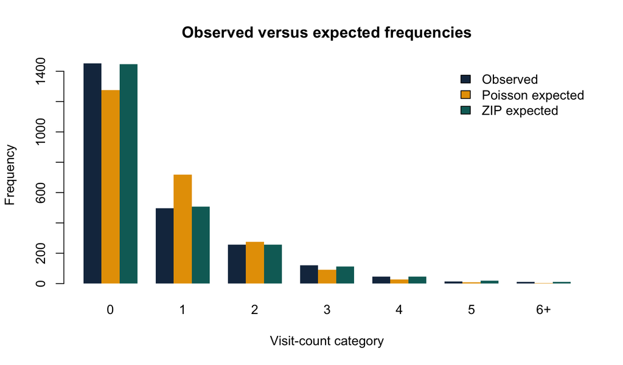

Observed count frequencies are compared with frequencies expected under the Poisson and ZIP models. Agreement across zero, small positive counts, and the pooled tail is more informative than a single fit statistic.

```r
barplot(
  t(as.matrix(frequency_check[, c("Observed", "Poisson_expected", "ZIP_expected")])),
  beside = TRUE, names.arg = frequency_check$Count_category,
  col = c(palette_count["navy"], palette_count["orange"], palette_count["teal"]),
  border = NA, xlab = "Visit-count category", ylab = "Frequency",
  main = "Observed versus expected frequencies"
)
legend("topright", legend = c("Observed", "Poisson expected", "ZIP expected"),
       fill = c(palette_count["navy"], palette_count["orange"], palette_count["teal"]), bty = "n")
```

## 5.2 Calibration is a prediction question

Calibration asks whether predicted outcomes agree with observed outcomes on the relevant scale and population. Group people by predicted marginal mean or zero probability, then compare observed and expected values. Internal apparent calibration can look excellent even when a model is overfit; use resampling or an external cohort for prediction claims.

```r
calibration_group <- cut(rank(zip_pred_all$marginal_mean, ties.method = "first"),
                         breaks = quantile(seq_len(nrow(count_data)), probs = seq(0, 1, 0.1)),
                         include.lowest = TRUE, labels = FALSE)
calibration <- aggregate(cbind(observed_visits = count_data$visits,
                               predicted_visits = zip_pred_all$marginal_mean,
                               observed_zero = count_data$visits == 0,
                               predicted_zero = zip_pred_all$observed_zero_probability) ~ calibration_group,
                         FUN = mean)
knitr::kable(calibration, digits = 3,
  caption = "Apparent ZIP calibration by deciles of predicted marginal mean")
```

Apparent ZIP calibration by deciles of predicted marginal mean

| calibration_group | observed_visits | predicted_visits | observed_zero | predicted_zero |
| --- | --- | --- | --- | --- |
| 1 | 0.179 | 0.179 | 0.850 | 0.851 |
| 2 | 0.300 | 0.281 | 0.767 | 0.779 |
| 3 | 0.392 | 0.361 | 0.717 | 0.731 |
| 4 | 0.396 | 0.450 | 0.717 | 0.682 |
| 5 | 0.546 | 0.536 | 0.646 | 0.641 |
| 6 | 0.600 | 0.639 | 0.613 | 0.587 |
| 7 | 0.729 | 0.768 | 0.546 | 0.534 |
| 8 | 0.987 | 0.943 | 0.458 | 0.470 |
| 9 | 1.167 | 1.189 | 0.417 | 0.421 |
| 10 | 1.858 | 1.811 | 0.317 | 0.329 |

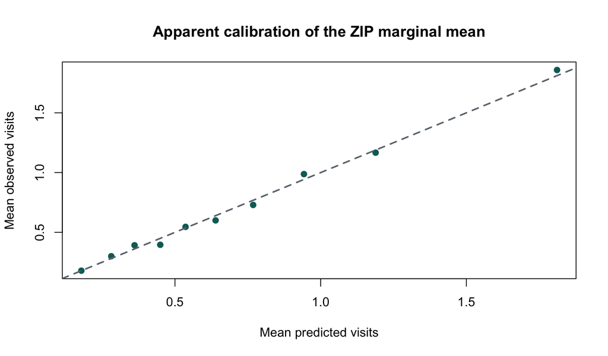

Calibration of the ZIP marginal mean across ten groups ranked by prediction. Points near the diagonal indicate agreement between average predicted and observed visit counts within these simulated data.

```r
plot(calibration$predicted_visits, calibration$observed_visits, pch = 19,
     col = palette_count["teal"], xlab = "Mean predicted visits", ylab = "Mean observed visits",
     main = "Apparent calibration of the ZIP marginal mean")
abline(0, 1, lty = 2, col = palette_count["gray"], lwd = 2)
```

## 5.3 AIC helps compare likelihoods, not theories

Poisson, NB, and ZIP likelihood-based AIC values can be compared only when they are fitted to the same outcome, rows, and likelihood convention. Quasi-Poisson has no ordinary likelihood AIC. A lower AIC reflects an estimated out-of-sample information criterion, not proof that structural zeros exist, that causal confounding is solved, or that predictions transport to another health system.

```r
zip_aic <- -2 * zip_fit$logLik + 2 * length(zip_fit$coefficients)
aic_table <- data.frame(
  Model = c("Poisson", "Negative binomial", "ZIP"),
  AIC = c(AIC(poisson_fit), AIC(nb_fit), zip_aic),
  Note = c("Single Poisson count process", "Extra-Poisson rate heterogeneity", "Poisson process plus structural-zero mixture")
)
knitr::kable(aic_table, digits = 1,
  caption = "AIC values for likelihood-based models fitted to the same simulated cohort")
```

AIC values for likelihood-based models fitted to the same simulated cohort

| Model | AIC | Note |
| --- | --- | --- |
| Poisson | 5400 | Single Poisson count process |
| Negative binomial | 5234 | Extra-Poisson rate heterogeneity |
| ZIP | 5086 | Poisson process plus structural-zero mixture |

# 6 ZIP versus hurdle models

A hurdle model also has two components, but all zeros come from the binary hurdle and the positive-count distribution is **zero-truncated**. Once the hurdle is crossed, a positive count is guaranteed. ZIP instead allows a susceptible person to have zero events through the Poisson process. The distinction should follow the process: a screening rule that blocks all recorded events may support a hurdle; participating care with a chance of no visit supports a ZIP-like mixture.

| Question | ZIP | Hurdle model |
| --- | --- | --- |
| Can the count process generate zero? | Yes | No; it is truncated at zero |
| What does the binary part model? | Structural-zero membership | Zero versus any positive count |
| What does a positive count imply? | Not structural zero | The hurdle was crossed |
| Is excess zeros enough to choose it? | No | No |

# 7 Design, clustering, and causal boundaries

## 7.1 The regression coefficient is usually an association

The program variable is randomized in this simulation only for illustration. In an observational study, program participation may reflect severity, access, prior utilization, clinic policy, or variables not measured. Adjustment can describe conditional associations; a causal rate effect needs an explicit target trial, temporal ordering, a well-defined intervention, no important unmeasured confounding, appropriate handling of selection and censoring, positivity, and a valid outcome-capture process.

Repeated visits within people, people within clinics, or neighborhoods within regions violate independence. Cluster-robust standard errors can address some inference issues with enough independent clusters; mixed-effects or generalized estimating equation approaches address different estimands and correlation structures. A ZIP likelihood that assumes independent rows is not repaired merely by adding many covariates.

Measurement systems can create the zeros Claims records, network boundaries, insurance changes, distance, and access barriers can determine whether an event is visible. Treat zero patterns as possible information-system behavior, not as intrinsic patient behavior. This matters for equity, transportability, and causal interpretation.

# 8 A complete analysis and reporting template

## 8.1 Summarize the main simulated analysis

```r
program_irr_pois <- exp(coef(poisson_fit)["programProgram"])
program_irr_nb <- exp(coef(nb_fit)["programProgram"])
program_irr_zip <- exp(zip_fit$coefficients["count_programProgram"])
case_summary <- data.frame(
  Result = c("Participants", "Observed zero-visit proportion", "Pearson dispersion", "Poisson program IRR", "NB program IRR", "ZIP count-component program IRR", "ZIP convergence"),
  Value = c(nrow(count_data), mean(count_data$visits == 0), pearson_dispersion,
            program_irr_pois, program_irr_nb, program_irr_zip, zip_fit$convergence)
)
knitr::kable(case_summary, digits = 3,
  caption = "Selected results from the simulated respiratory ED-visit analysis")
```

Selected results from the simulated respiratory ED-visit analysis

| Result | Value |
| --- | --- |
| Participants | 2400.000 |
| Observed zero-visit proportion | 0.605 |
| Pearson dispersion | 1.363 |
| Poisson program IRR | 0.776 |
| NB program IRR | 0.779 |
| ZIP count-component program IRR | 0.770 |
| ZIP convergence | 0.000 |

In this simulated cohort, 60.5% of people had no recorded respiratory ED visit. The Poisson Pearson dispersion was 1.36, indicating that a one-process Poisson variance was inadequate. The adjusted program IRR was 0.78 in the Poisson model, 0.78 in the negative binomial model, and 0.77 for the ZIP count component. The ZIP model also estimates a separate structural-zero mechanism. These are model-based associations in simulated data; a favorable fit does not prove a care-capture mechanism or establish a causal program effect.

### 8.1.1 Auditable reporting template

> We analyzed **[count definition]** observed over **[person-time definition]** among **[population and dates]**. The primary estimand was **[conditional rate ratio, marginal predicted count, prediction objective, or causal estimand]**. We modeled the count using **[Poisson/NB/ZIP]** with `offset(log([person-time]))` and adjusted for **[prespecified covariates]**. We reported **[IRR or other measure]** with 95% confidence intervals and absolute predicted outcomes for **[named covariate profiles]**. We assessed **[dispersion, zero frequency, functional form, dependence, calibration]**. The observed zero process was interpreted as **[measurement/process rationale]**, and limitations included **[missingness, clustering, residual confounding, capture boundaries, transportability]**.

# 9 Common Errors at a Glance

| Error | Why it is wrong | Better approach |
| --- | --- | --- |
| Model a rate as ordinary Gaussian data | Rates have denominator-dependent variance and can be skewed | Model the count and offset its log person-time |
| Interpret an IRR as a risk ratio | Rate and cumulative risk are distinct | State the event-time scale and report absolute predictions |
| Treat the offset coefficient as estimated | It is fixed at one by design | Verify the person-time definition and use `offset(log(time))` |
| Ignore overdispersion | Poisson standard errors can be too small | Diagnose causes and consider quasi-Poisson, NB, clustering, or a better mean model |
| Choose ZIP because a histogram has many zeros | Multiple mechanisms can create zeros | Articulate and test the measurement/process rationale |
| Read ZIP $\mu$ as the population mean | It is conditional on the nonstructural process | Report $(1-\pi)\mu$ when that is the target |
| Call a zero-component odds ratio an observed-zero odds ratio | ZIP zero component is structural-zero membership | Name the model component and scale explicitly |
| Compare quasi-Poisson by AIC | It has no ordinary likelihood AIC | Compare predictive performance or likelihood models appropriately |
| Ignore repeated rows or clinics | Independence-based uncertainty can fail | Use a design-appropriate correlated-data method |
| Claim causality from adjusted count regression | Covariate adjustment does not solve all bias | Define the causal target and identification assumptions |

# 10 Exercises and Answers

1. A person has two visits in 0.5 person-years. Is the outcome count, rate, or risk?
2. Why is `offset(log(person_years))` used instead of `offset(person_years)`?
3. A Poisson model has Pearson dispersion 2.4. Name three possible explanations.
4. In ZIP, what is the expected observed count for $\mu=1.2$ and $\pi=0.25$?
5. Does a lower ZIP AIC prove that some people are structurally unable to have an event?
6. What prediction would you report for a clinician choosing between two one-year program profiles?

**Show exercise answers**

1. The recorded outcome is a count of two; dividing by 0.5 gives a rate of four visits per person-year. A risk would require a specified probability of at least one event in a fixed period.
2. The log link makes the expected count proportional to person-time: $\log(\mu)=\log(t)+\eta$. Using raw person-time as an offset imposes an implausible exponential relation in $t$.
3. Examples include omitted heterogeneity in event rates, within-clinic or within-person dependence, an incorrect functional form, an NB-like mixture, and measurement or structural-zero processes.
4. The marginal mean is $(1-0.25)\times1.2=0.90$ observed visits.
5. No. AIC is a relative likelihood-based fit criterion; it cannot establish the substantive mechanism, causality, or generalizability.
6. Report each profile’s marginal expected count and probability of at least one/zero visit, specify that follow-up is one year, and show uncertainty if the prediction will guide decisions.

# 11 Quick Reference

## 11.1 Formulas and R entry points

| Target | Formula or code | Interpretation |
| --- | --- | --- |
| Poisson rate model | `glm(y ~ x + offset(log(time)), family = poisson)` | Conditional mean count proportional to time |
| IRR | $\exp(\beta_j)$ | Multiplicative conditional rate comparison |
| Poisson zero probability | $e^{-\mu}$ | Probability of no event in one-process Poisson model |
| Pearson dispersion | $\sum r_P^2/(n-p)$ | Descriptive check for extra variation |
| Quasi-Poisson | `family = quasipoisson` | Mean model with scale-adjusted uncertainty |
| Negative binomial | `MASS::glm.nb(...)` | Count model with extra-Poisson heterogeneity |
| ZIP zero probability | $\pi+(1-\pi)e^{-\mu}$ | Structural plus Poisson sources of zero |
| ZIP marginal mean | $(1-\pi)\mu$ | Expected observed count across both processes |
| ZIP fitting here | `fit_zip(count_formula, zero_formula, data)` | Transparent MLE with `optim()` and Hessian SEs |

## 11.2 Final checklist

- Is the event a valid nonnegative count and is the observation period explicit?
- Is person-time positive, aligned with the count, and included as a log offset?
- Are rate, risk, expected count, and zero probability kept distinct?
- Are IRRs accompanied by confidence intervals and understandable absolute predictions?
- Were dispersion, functional form, influential observations, and row dependence investigated?
- Is the rationale for a zero mixture grounded in a measurement or event process rather than a zero bar alone?
- Are both ZIP components and the marginal prediction scale labeled clearly?
- Were observed-versus-predicted frequencies and calibration examined?
- Are AIC comparisons restricted to comparable likelihood-based fits and not overinterpreted?
- Do missing-data, clustering, selection, and causal claims match the study design?

## Next directions for study

Next topics include zero-inflated negative binomial models, hurdle models, splines for nonlinear rates, distributed lags, recurrent-event survival models, generalized estimating equations, mixed-effects count models, cluster-robust inference, Bayesian hierarchical count models, and externally validated prediction models.

**For teaching only:** This module introduces count-rate regression, overdispersion, zero-inflated modeling, diagnosis, and reporting. It does not replace a study-specific analysis plan, outcome-capture audit, or consultation with a biostatistician. All data and numerical results are simulated.